# Assignment 3

Mario Perales

February 8, 2016

*Source file* ⇒ Homework3.Rmd

# Monday February 1

## 5-4

In order to modify the CPS85 file accordingly, we must first execute the following *R* Code.

```r
scatterGraphHelper(CPS85)
```

Then in the drop down menu, you would set:

- x-axis = exper
- y-axis = wage
- color = married
- facet = sector

to produce the following graph:

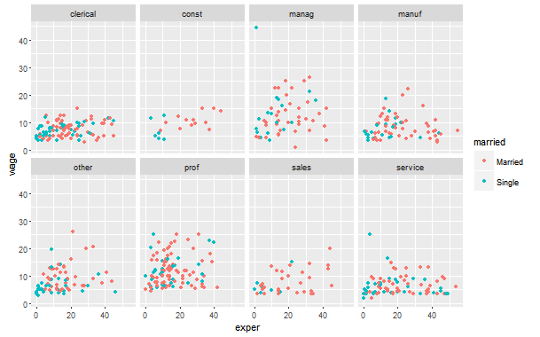

## 6-3

1. The geometric feature of the *second glyph* is **two asteriks** while the gemoetric figure of the *other glpyh* is a **line**. The *asteriks* glyph is mapped from the **signif** variable. Meanwhile, the *other glyph* is mapped from the **protein** variable.
2. The *y-axis* is defined by the variables **high** and **low** while the *x-axis* is defined by the variable **protein**.
3. No.
4. There are tick marks along the y-axis which are guides. That is the only guide.

## 6-6

4. Glyph: Rectangle. Graphical attribute: color and text.

## 6-8

As before, we must execute the following *R* code to change produce the graph.

```r
Small <-
  NCHS >%>
  sample_n(size=5000)
```

```r
scatterGraphHelper(Small)
```

You then change the following attributes:

- x-axis = bmi
- y-axis = weight
- color = smoker

To get the following graph:

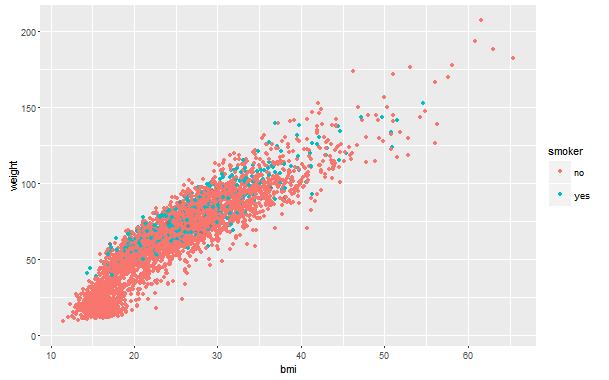

We see that *bmi* is mapped to the **horizontal position**, *weight* is mapped to the **vertical position** and finally *smoker* is mapped to **color**.

# Wednesday February 3

## 6.2

1. There are **five** guides. There is table guide of 8 entries which tells us that the variable *molecule* corresponds to the graphical attribute **color**. There is another table element guide with two entries that tells us that the variable *flux* corresponds to the graphical attribute of **filled dot**. The bottom x-axis is a guide which informs us that the variable *gene* corresponds to the graphical element of **lower x-axis tick marks**. The y-axis provides a similar guide which informs us that the variabe *concentration* is mapped to the graphical elements **y-axis tick marks**. Lastly, the top x-axis is a guide which informs us that the variable *target* corresponds to the graphical attribute of **brackets**.
2. The graphical attributes of the dots are:
- **color** - Mapped by the variable *molecule*
- **fill** - Mapped by the variable *flux*
- **horizontal position** - Mapped by *gene*
- **vertical position** - mapped by *concentration*
3. The variables *concentration* and *gene* set the frame.
4. They are set by the variables *gene* and *target*.

## 7.2

1. You would exectute the following *R* code:

```r
diamonds %>%
  group_by(color) %>%
  summarise(average = mean(carat)) %>%
  arrange(desc(average)) %>%
  head(1)
```

```
## Source: local data frame [1 x 2]
##
##    color  average
##   (fctr)    (dbl)
## 1      J 1.162137
```

2. The clarity of diamond which has the largest “table” per carat is given by the *R* code:

```r
diamonds %>%
  group_by(clarity) %>%
  summarise(avg = mean(table/carat)) %>%
  arrange(desc(avg)) %>%
  head(1)
```

```
## Source: local data frame [1 x 2]
##
##   clarity      avg
##    (fctr)    (dbl)
## 1    VVS1 141.4822
```

## 7.4

- A. The argument **“First”** in group_by is not a variable of the DataTable *BabyNames*. Thus there is a syntax error.
- B. You are trying to create a variable *Tmp* but you are also using it in its definition as an argument to *summarise*. Also, there is no need to pipe the data table from group_by to summarise because summarise already has a data table as its argument (thus making the piping redundant).
- C. You define the variable Tmp but never use it.

## 7.5

1. You would write the following *R* code:

```r
BabyNames %>%
  group_by(sex)
```

2. You would write the following *R* code:

```r
BabyNames %>%
  filter(sex == "F")
```

3. You would do the same as b but in filter, your argument will be (sex == “M”)
4. You would write the following *R* code:

```r
BabyNames %>%
  summarise(total = sum(count))
```

5. You would write the following *R* code:

```r
BabyNames %>%
  select(name, count)
```

# Friday February 5

## 7.6

1. Using this *R* code gives us the number of cases:

```r
nrow(Minneapolis2013)
```

```
## [1] 80101
```

2. The following *R* code gives us the top 5 candidates under the *Second* vote selection:

```r
Minneapolis2013 %>%
  group_by(Second) %>%
  summarise(count = n()) %>%
  arrange(desc(count)) %>%
  head(5)
```

```
## Source: local data frame [5 x 2]
##
##               Second count
##                (chr) (int)
## 1       BETSY HODGES 14399
## 2        DON SAMUELS 14170
## 3        MARK ANDREW 12757
## 4          undervote 10598
## 5 JACKIE CHERRYHOMES  6470
```

3. The number of ballots for each category is given by the following *R* codes:
- *First* choice selections:

```r
Minneapolis2013 %>%
  filter(First == "undervote") %>%
  nrow()
```

```
## [1] 834
```

- *Second* choice selections:

```r
Minneapolis2013 %>%
  filter(Second == "undervote") %>%
  nrow()
```

```
## [1] 10598
```

- *Third* choice selections:

```r
Minneapolis2013 %>%
  filter(Third == "undervote") %>%
  nrow()
```

```
## [1] 19210
```

4. To get the top three combinations of *First* and *Second* vote selections, we would use the following *R* code:

```r
Minneapolis2013 %>%
  group_by(First, Second) %>%
  summarise(total = n()) %>%
  ungroup() %>%
  arrange(desc(total)) %>%
  head(3)
```

```
## Source: local data frame [3 x 3]
##
##          First       Second total
##          (chr)        (chr) (int)
## 1 BETSY HODGES  MARK ANDREW  8787
## 2 BETSY HODGES  DON SAMUELS  8743
## 3  MARK ANDREW BETSY HODGES  6970
```

5. This *R* code gives the highest number of ballots cast by a precinct:

```r
Minneapolis2013 %>%
  group_by(Precinct) %>%
  summarise(count = n()) %>%
  arrange(desc(count)) %>%
  head(1)
```

```
## Source: local data frame [1 x 2]
##
##   Precinct count
##      (chr) (int)
## 1     P-06  9711
```

## 8.1

1. Construct the graphics frame.
- 3. ggplot()
2. Add a layer of glyphs.
- 1. geom_point()
- 2. geom_histogram()
- 7. geom_segment()
3. Set an axis label.
- 5. ylab()
- 8. xlim()
4. Divide the frames into facets.
- 6. facet_wrap()
5. Change the scale for the frame.
- 4. scale_y_log10()

## 8.2

1. To produce the first graph, we execute the following *R* code:

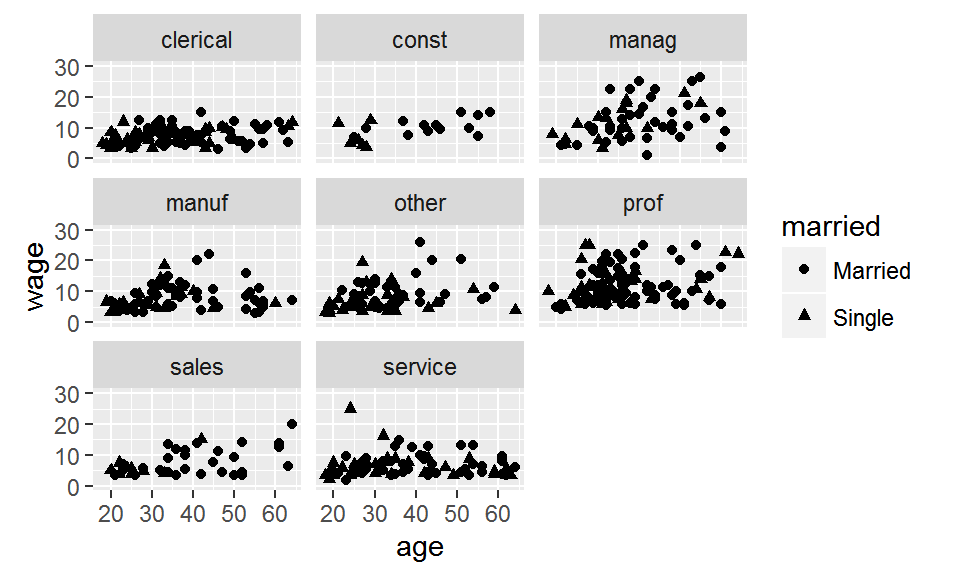

```r
mosaicData::CPS85 %>%
  ggplot(aes(x = age, y = wage)) +
  geom_point(aes(shape = married)) +
  facet_wrap( ~ sector) +
  ylim(0,30)
```

2. To produce the second graph, we execute the following *R* code:

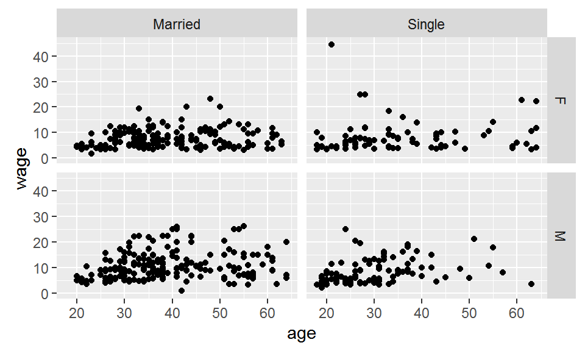

```r
mosaicData::CPS85 %>%
  ggplot(aes(x = age, y = wage)) +
  geom_point() +
  facet_grid(sex ~ married) +
  ylim(0,45)
```